# 空间数据分析

2025-07-20

## 1 学习目标

- 描述空间计量经济学的动机
- 理论与实证动因
- 进行基本的空间描述与相关性检验（R语言）
- 可视化与结果解读
- 选择并应用关键的空间模型（R语言）
  - 空间误差模型（SEM）、空间自回归模型（SAR）、空间杜宾模型（SDM）
- 正确解读空间回归结果
- 实践操作

## 2 为什么要使用空间计量模型？

- 地理位置和空间结构重要，存在空间相关性
- 传统计量经济模型假设观测单位独立，忽略空间互动，可能导致估计偏差和不一致
- 需要建模空间依赖性，以获得有效推断结果

## 3 理论基础

- **地理学第一定律**（Tobler，1970）：**“一切事物都是相关的，但近的事物比远的更相关。”**
- **溢出效应**：一个地区的结果受邻近地区影响
- **战略相互依赖**：个体根据邻居行为反应（如税收竞争）
- **遗漏变量偏差**：空间相关但不可观察的因素

## 4 空间过程与模型匹配

| 动机 | 含义 | 模型 |
| --- | --- | --- |
| i.i.d.假设被破坏 | 空间自相关误差项 | SEM |
| 溢出效应 | 滞后因变量起作用 | SAR |
| 战略互动 | 内生空间依赖 | SAR、SDM |
| 遗漏变量 | 相关误差项 | SEM |
| 政策扩散 | 间接/溢出效应 | SDM |

## 5 实证动因 - 实际案例

- 城市经济学：房价、急救响应、污染
- 公共财政：税收模仿、支出溢出
- 区域发展：基础设施跨区域影响
- 流行病学：疾病传播模式
- 忽略空间效应会低估政策影响或误判显著性水平

## 6 空间滞后

- 空间滞后是时间序列相关性的空间类比，但更为复杂。
- 主要区别：
  - 空间滞后是多方向关系，而时间序列相关性是单方向（只能过去影响未来）。
  - 空间滞后会消耗自由度，而时间序列相关性不会。
  - 空间滞后使用预定义的空间权重矩阵（W），而时间序列相关性没有。
  - 空间滞后性可比较不同的W矩阵以获得稳健性结果。

空间异质性？？

## 7 何时考虑空间回归？

- 每个观测值对应一个空间位置或区域
- 一定要进行探索性空间数据分析以识别空间相关性

## 9 空间权重矩阵（W）

- 描述空间单位间的结构或连通性
- 常为n×n稀疏矩阵，行标准化（行和为1）

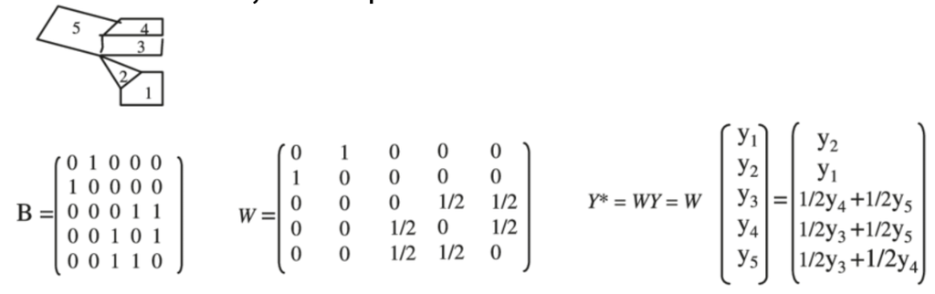

空间权重矩阵

- **连通型矩阵**
  - **Rook邻接**：共享边界的邻居
  - **Queen邻接**：共享边界或角落的邻居
  - 示例：中心单元（E）的邻居
    - Rook：B、D、F、H
    - Queen：A、B、C、D、F、G、H、I

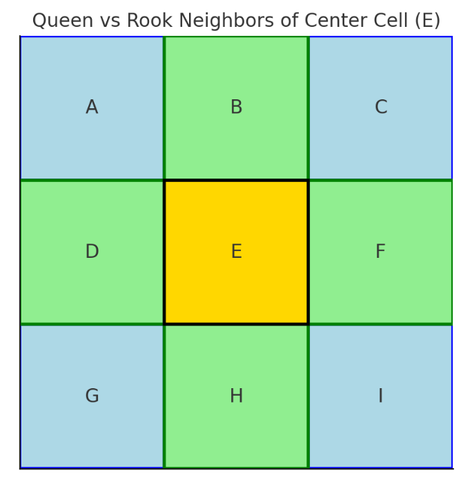

### 9.1 距离型矩阵：

- 反距离权重：1/d^2
- 距离带法：指定范围内为邻居
- K近邻：最近的K个单位为邻居

### 9.2 非地理型矩阵：

- 社交连接：谁与谁在社交网络中互动
- 经济相似性：哪些公司属于同一行业或具有相似财务特征
- 功能关系：组织内哪些部门在项目中合作
- 共享属性：哪些个体具有相似的年龄、收入或政治观点

## 10 如何选择 W？

- W矩阵的设定具有一定的主观性
- 不设W（即设为0）意味着假设空间独立，反而更强
- 不同W可能导致参数估计差异（尤其在早期文献中）
- 实证研究会有许多不同的矩阵设定，通过敏感性分析消除疑虑

## 11 Shapefile 简介

- ESRI开发的地理矢量数据格式
- 常见文件包括：`.shp`, `.shx`, `.dbf` 等

## 12 案例数据

- 数据集：NC（spData 或 spdep 包）
- 范围：北卡罗来纳州100个县
- **变量**：
- BIR74, BIR79：1974年和1979年的出生数
- SID74, SID79：1974年和1979年的婴儿猝死数
- NWBIR74, NWBIR79：1974年和1979年非白人母亲的出生数
- NAME, FIPS, CNTY_ID：县标识符和名称
- **来源与原始出版**：
  - 原始研究：Cressie, Noel. (1993). *Statistics for Spatial Data*. Wiley.
  - 由Luc Anselin等人编译，最初用于空间计量建模
  - 参考文献：Bivand, Roger S., Edzer J. Pebesma, and Virgilio Gómez-Rubio (2008, 2013). *Applied Spatial Data Analysis with R*.
- 读取数据与呈现

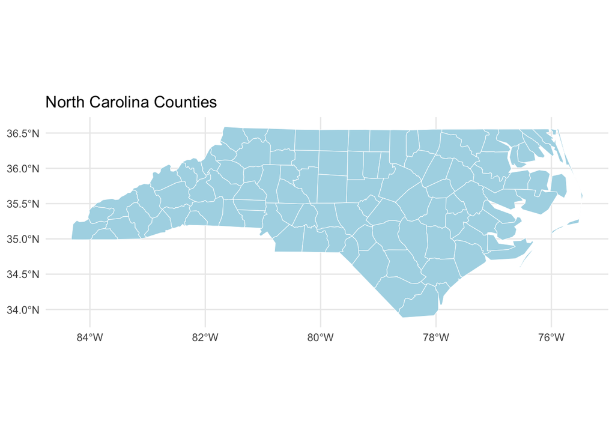

```r
library(sf)
library(spdep)
library(ggplot2)
library(leaflet)
library(spatialreg)
library(lmtest)
library(stargazer)
library(gt)
library(dplyr)
# 载入shp文件
nc <- st_read(system.file("shape/nc.shp", package="sf"))
# 将空间数据转换为WGS84经纬度坐标系，便于与其他通用地理数据或工具（如Leaflet、ggplot2等）兼容
nc <- st_transform(nc, crs = 4326)

# 可视化
ggplot(nc) +
  geom_sf(fill = "lightblue", color = "white") +
  theme_minimal() +
  labs(title = "North Carolina Counties")
```

```r
# 采用leaflet包创建交互式地图
pal <- colorNumeric("YlGnBu", domain = NULL)  # 可根据需要定义变量

leaflet(nc) %>%
  addTiles() %>%
  addPolygons(
    fillColor = ~pal(1),  # 可根据变量选定颜色
    fillOpacity = 0.6,
    color = "black",
    weight = 1,
    popup = ~paste("ID:", row.names(nc))
  )
```

[interactive chart not shown]

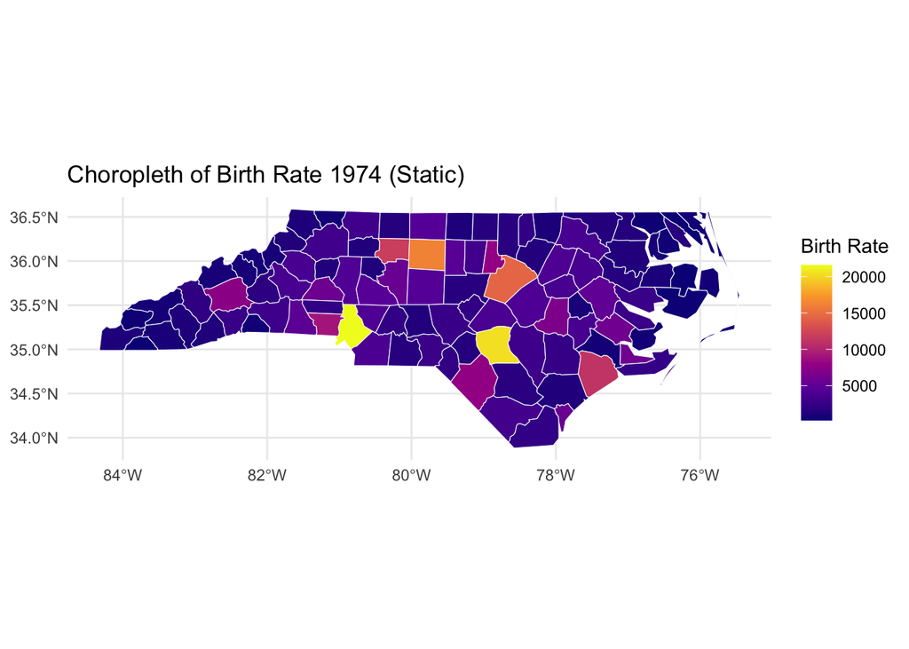

```r
# 采用ggplot2绘制静态地图

ggplot(nc) +
  geom_sf(aes(fill = BIR74), color = "white") +
  scale_fill_viridis_c(option = "C", name = "Birth Rate") +
  theme_minimal() +
  labs(title = "Choropleth of Birth Rate 1974 (Static)")
```

```r
# 采取leaflet绘制交互式地图
pal <- colorNumeric(palette = "YlOrBr", domain = nc$BIR74)

leaflet(nc) %>%
  addTiles() %>%
  addPolygons(
    fillColor = ~pal(BIR74),
    fillOpacity = 0.7,
    color = "black",
    weight = 1,
    popup = ~paste("Birth Rate:", BIR74)
  ) %>%
  addLegend("bottomright", pal = pal, values = ~BIR74,
            title = "Birth Rate")
```

[interactive chart not shown]

- 空间连通性

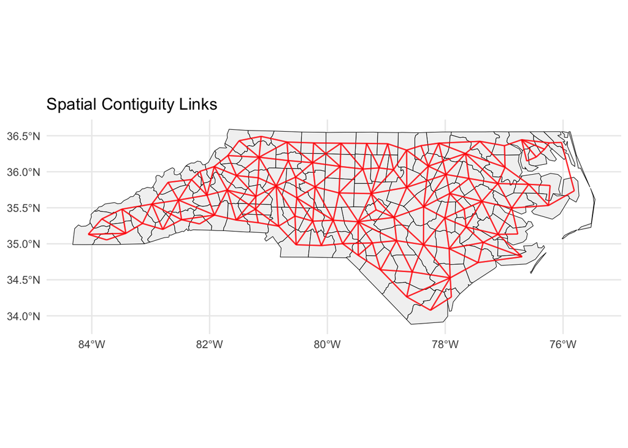

```r
# 创建连通加权矩阵（queen）
nb_contig <- poly2nb(nc) # 从多边形生成邻居列表
listw_contig <- nb2listw(nb_contig, style = "W") # 添加按行标准化的权重

# 可视化连通性
centroids <- st_centroid(st_geometry(nc))
coords <- st_coordinates(centroids) # 获取地理单元的中心点及其坐标

nb_lines <- nb2lines(nb_contig, coords = coords, as_sf = TRUE)
st_crs(nb_lines) <- st_crs(nc)  # 将邻居列表转化为空间线条数据框，并附加坐标系

# 呈现邻居连通性
ggplot() +
  geom_sf(data = nc, fill = "grey95", color = "black") +
  geom_sf(data = nb_lines, color = "red", size = 0.5, alpha = 0.6) +
  theme_minimal() +
  labs(title = "Spatial Contiguity Links")
```

- 全局莫兰检验和呈现

```r
# 莫兰检验和呈现
moran.test(nc$BIR74, listw = listw_contig)
```

```
##
##  Moran I test under randomisation
##
## data:  nc$BIR74
## weights: listw_contig
##
## Moran I statistic standard deviate = 2.4055, p-value = 0.008074
## alternative hypothesis: greater
## sample estimates:
## Moran I statistic       Expectation          Variance
##       0.139319332      -0.010101010       0.003858258
```

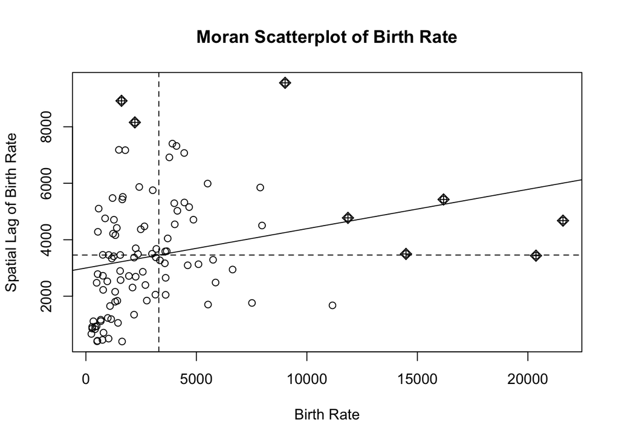

```r
moran.plot(nc$BIR74, listw = listw_contig,
           labels = FALSE, xlab = "Birth Rate",
           ylab = "Spatial Lag of Birth Rate",
           main = "Moran Scatterplot of Birth Rate")
```

- 局部空间相关指数（LISA）的呈现

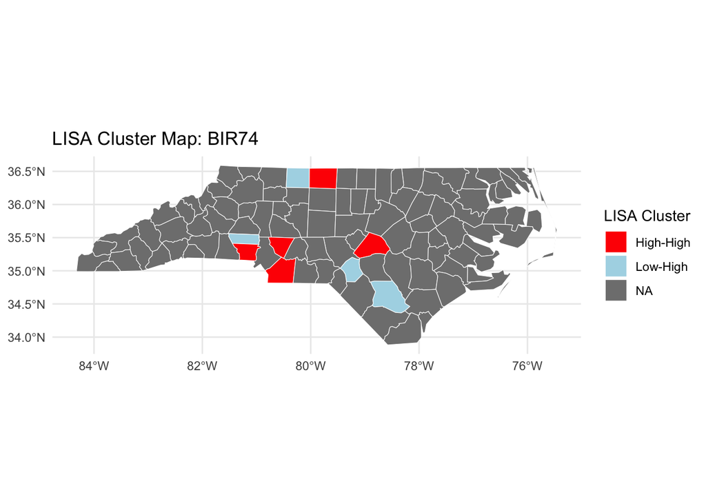

```r
# 利用空间权重矩阵，获取变量的空间滞后项
nc$lag_BIR <- lag.listw(listw_contig, nc$BIR74)

# 基于空间权重，分别计算每个地理单元局部莫兰指数
local_moran <- localmoran(nc$BIR74, listw=listw_contig)

# 添加局部莫兰指数的结果，包括指数统计量、标准差、显著性水平
nc$Ii     <- local_moran[, "Ii"]
nc$Z_Ii   <- local_moran[, "Z.Ii"]
nc$p_Ii   <- local_moran[, "Pr(z != E(Ii))"]

# 划分LISA集合的类别
# Global means
mean_BIR <- mean(nc$BIR74, na.rm = TRUE)
mean_lag <- mean(nc$lag_BIR, na.rm = TRUE)
nc$cluster <- factor(
  ifelse(nc$BIR74 > mean_BIR & nc$lag_BIR > mean_lag & nc$p_Ii <= 0.05, "High-High",
         ifelse(nc$BIR74 < mean_BIR & nc$lag_BIR < mean_lag & nc$p_Ii <= 0.05, "Low-Low",
                ifelse(nc$BIR74 > mean_BIR & nc$lag_BIR < mean_lag & nc$p_Ii <= 0.05, "High-Low",
                       ifelse(nc$BIR74 < mean_BIR & nc$lag_BIR > mean_lag & nc$p_Ii <= 0.05, "Low-High",
                              "Not Significant")))),
  levels = c("High-High", "Low-Low", "High-Low", "Low-High", "Not Significant")
)

# Optional: Make sure 'cluster' is a factor with proper levels
nc$cluster <- factor(nc$cluster, levels = c("High-High", "Low-Low", "High-Low", "Low-High", "Not significant"))

# Define custom colors for each cluster type
cluster_colors <- c(
  "High-High" = "red",
  "Low-Low" = "blue",
  "High-Low" = "orange",
  "Low-High" = "lightblue",
  "Not significant" = "lightgray"
)

# Plot using ggplot
ggplot(nc) +
  geom_sf(aes(fill = cluster), color = "white", size = 0.2) +
  scale_fill_manual(values = cluster_colors, name = "LISA Cluster") +
  labs(title = "LISA Cluster Map: BIR74") +
  theme_minimal()
```

## 13 基本模型规格

- **空间误差模型（SEM）**：Y = α + Xβ + μ, μ = ρWμ + ε
- **空间自回归模型（SAR）**：Y = α + ρWY + Xβ + ε
- **空间杜宾模型（SDM）**：Y = α + ρWY + Xβ + WXβ + ε
- **模型嵌套关系**：
  - SDM嵌套SAR和SEM模型
  - 使用测试程序指导简化
  - SDM是最通用的（灵活的）模型

## 14 OLS残差的空间依赖性测试

- **零假设**：无空间依赖性
- **两种变体**：
  - LM-lag：测试SAR模型
  - LM-error：测试SEM模型
- 当两者均显著时，使用稳健LM测试

## 16 空间参数估计（ρ 和 λ）

- 示例：p = 1, p = 0.5, p = 0.1

## 18 空间矩阵

- 矩阵是对角矩阵 (I - ρW)^(-1)

## 19 建议

- 始终测试空间依赖性
- 如有疑问，优先选择SDM模型，然后测试简化为SAR或SEM
- 当模型不明确时，使用稳健LM测试
- 谨慎解释SDM效应

## 20 空间面板

- **双向固定效应**：时间与空间
- **多种空间模型规格**：
  - 参考文献：Cheng and Guo (2021); Han, Xiong, Cheng, and Guo (2022); Guo and Cheng (2018)
- **动态空间面板**：
  - 因变量不仅在时间上相关，还在空间上相关
  - 参考文献：Cheng, Guo, and Liu (2020)
- **空间Probit模型**：
  - 二元或多项因变量
- **空间多层次/层级模型**：
  - 嵌套结构（如城市嵌入省份）
- **社交网络分析中的空间模型**

## 21 基本空间模型

- **OLS**：Y = α + Xβ + ε
- **SEM**：Y = α + Xβ + μ，μ = ρWμ + ε
- **SAR**：Y = α + ρWY + Xβ + ε
- **SDM**：Y = α + ρWY + Xβ + WXθ + ε

SDM 是最通用的模型，嵌套 SAR 与 SEM

## 22 模型选择流程

### 22.1 从具体到一般：

1. 拟合OLS
2. 对残差进行LM检验
   - LM-lag 检测SAR
   - LM-error 检测SEM
   - 若均显著，用R-LM检验
3. 若确认存在空间依赖，拟合 SDM
4. 使用 LR 检验比较 SDM 与 SAR/SEM

## 23 SDM 与 SAR 中的效应

- SAR 中 β 不能直接解释为边际效应
- 空间反馈机制需通过逆矩阵表示
- LeSage & Pace（2014）：即使W不同，最终的效应矩阵（I - ρW）⁻¹ 乘以 β 很稳定

### 23.1 效应类型：

- **直接效应**：对自身的平均影响（主对角线均值）
- **总效应**：每行和的平均值
- **间接效应**：总效应 - 直接效应

## 24 实用建议

- 一定要检测空间依赖性
- 若不确定，先用 SDM，再通过检验简化
- 解释 SDM 效应时要小心

## 25 拓展方向

- 空间面板模型（双向固定效应）
- 动态空间面板
- 空间 Probit（二值/多项）模型
- 多层/层级空间模型
- 社会网络中的空间分析

## 26 推荐文献

- Anselin (1988). *Spatial Econometrics: Methods and Models*
- LeSage & Pace (2009). *Introduction to Spatial Econometrics*
- LeSage & Pace (2014). https://doi.org/10.3390/econometrics2040217
- Bivand et al. (2013). *Applied Spatial Data Analysis with R*
- Cheng & Guo (2021). https://doi.org/10.1080/03003930.2020.1794845
- Guo & Cheng (2017). https://doi.org/10.52324/001c.8009

## 27 有问题或评论？

**感谢您的参与！**

郭海老师提到的用到spatial analysis的论文。供大家参考。https://onlinelibrary.wiley.com/doi/abs/10.1111/pbaf.12160 https://www.tandfonline.com/doi/abs/10.1080/23276665.2022.2071305